# GSGS

# GS 유통데이터 분석

# 1. 미세먼지의 좋고나쁨과 매출의 높고낮음이 연관이 있는 행정동

### 필요한 라이브러리 로드

```r
library(tidyverse)
```

### 필요한 데이터 로드

```r
gs = read_rds('./complete/gs.rds')
cd = read_rds('./complete/cd.rds')
wk = read_rds('./complete/요일주말DTgb.rds')
kwk = read_rds('./complete/요일주말DTgb_kweather.rds')

gs.kgb = as_tibble(read.csv("./complete/gs동별gb_kweather.csv"))

comparison_real_vs_forecast = read_rds('./complete/comparison_real_vs_forecast.rds')
```

##### GS데이터 이상치 제거

```r
gs = gs %>% filter(!DT %in% c(20180214, 20180314, 20181110, 20181111))
```

##### GS데이터의 HDONG_CD에 행정동명을 붙이자

```r
gs2 = gs %>% left_join(cd, by = "HDONG_CD")
```

##### 일별, 동별로 GS데이터와 미세먼지 좋고 나쁨을 key = DT로 붙이자.

```r
gs5= gs2 %>% left_join(kwk, by = c("DT", "HDONG_CD"))
```

```r
gs4 = gs2 %>% left_join(kwk, by = c("HDONG_CD", "DT")) %>%
      group_by(HDONG, DT, weekend, gb ) %>%
       summarise(mAMT = mean(AMT_IND, na.rm = T),
            m10 = mean(LCLS_10_P, na.rm = T) , m20 = mean(LCLS_20_P, na.rm = T) ,
            m30 = mean(LCLS_30_P, na.rm = T) , m40 = mean(LCLS_40_P, na.rm = T) ,
            m50 = mean(LCLS_50_P, na.rm = T) , m60 = mean(LCLS_60_P, na.rm = T) ,
            m70 = mean(LCLS_70_P, na.rm = T) , m80 = mean(LCLS_80_P, na.rm = T) )
gs4$DT = parse_date(as.character(gs4$DT), "%Y%m%d")

kf2 = comparison_real_vs_forecast %>% group_by(DT, HDONG_CD) %>% summarise(f10m = mean(f10), f25m = mean(f25))
kf2[kf2$f10m<2 & kf2$f25m<2,"gb"] = "kgood"
kf2[kf2$f10m>2 & kf2$f25m>2,"gb"] = "kbad"
kwk = right_join(kf2, wk[,-4], by = "DT") %>% select(DT,day, weekend, HDONG_CD,gb) %>% arrange(DT)
write_rds(kwk, "요일주말DTgb_kweather.rds")

kf3 = kf2 %>% group_by(DT) %>% summarise(f10m = mean(f10m), f25m = mean(f25m))
kf3[kf3$f10m<2 & kf3$f25m<2, 'gb'] = 'kgood'
kf3[kf3$f10m>2 & kf3$f25m>2, 'gb'] = 'kbad'
kf3$DT =  parse_date(as.character(kf3$DT),"%Y%m%d")

gs4.sum = gs4 %>% group_by(DT) %>% summarise(mAMT = mean(mAMT, na.rm = T))
gs4.sum = left_join(gs4.sum, kf3, by = 'DT')
```

##### 각 동별로 GS총매출 좋은날, 나쁜날을 나누어보자. 기준은 각 동마다의 총매출 중앙값이다.

##### 동별로, GS총매출의 높은날과 낮은날 그리고 kweather 미세먼지 데이터 좋은날 나쁜날의 2x2 table생성을 해서 보자

```r
for(i in 1:36){
   hdong = unique(gs5$HDONG)[i]
   for_gs = gs5 %>% filter(HDONG == hdong)
   hdong_med = median(for_gs$AMT_IND, na.rm = T)
   for_gs$COUNT = ifelse(for_gs$AMT_IND > hdong_med,"upper", "lower")
   print('')
   print(paste0(hdong,"총매출 lower upper와 kweather 미세먼지 bad good에 대한 2x2 table"))
   print(table(for_gs$COUNT, for_gs$gb))
   }
```

```
## [1] ""
## [1] "J청운효자동총매출 lower upper와 kweather 미세먼지 bad good에 대한 2x2 table"
##
##         kbad kgood
##   lower   76    58
##   upper   44    93
## [1] ""
## [1] "J사직동총매출 lower upper와 kweather 미세먼지 bad good에 대한 2x2 table"
##
##         kbad kgood
##   lower   39    78
##   upper   41    75
## [1] ""
## [1] "J삼청동총매출 lower upper와 kweather 미세먼지 bad good에 대한 2x2 table"
##
##         kbad kgood
##   lower   71    58
##   upper   49    69
## [1] ""
## [1] "J부암동총매출 lower upper와 kweather 미세먼지 bad good에 대한 2x2 table"
##
##         kbad kgood
##   lower   66    60
##   upper   59    60
## [1] ""
## [1] "J평창동총매출 lower upper와 kweather 미세먼지 bad good에 대한 2x2 table"
##
##         kbad kgood
##   lower   81    44
##   upper   48    63
## [1] ""
## [1] "J무악동총매출 lower upper와 kweather 미세먼지 bad good에 대한 2x2 table"
##
##         kbad kgood
##   lower   86    49
##   upper   41    82
## [1] ""
## [1] "J교남동총매출 lower upper와 kweather 미세먼지 bad good에 대한 2x2 table"
##
##         kbad kgood
```

[output cut: 161 more lines]

```
##         kbad kgood
##   lower   38    71
##   upper   61    63
## [1] ""
## [1] "N상계9동총매출 lower upper와 kweather 미세먼지 bad good에 대한 2x2 table"
##
##         kbad kgood
##   lower   94    41
##   upper   56    73
## [1] ""
## [1] "N상계10동총매출 lower upper와 kweather 미세먼지 bad good에 대한 2x2 table"
##
##         kbad kgood
##   lower   64    50
##   upper   35    85
```

### 위의 table data를 가지고 2x2 교차검정 chi-squre test해보자.

##### 미세먼지의 좋고나쁨과 GS총매출의 높고낮음이 서로 독립인지 카이제곱검정을 해보았다.

##### 귀무가설: 미세먼지의 좋고나쁨과 GS총매출의 높고낮음은 서로 독립이다. 서로 연관이 없다.

##### 대립가설: 미세먼지의 좋고나쁨과 GS총매출의 높고낮음은 서로 독립이 아니고 연관이 있다.

```r
for(i in 1:36){
   hdong = unique(gs5$HDONG)[i]
   for_gs = gs5 %>% filter(HDONG == hdong)
   hdong_med = median(for_gs$AMT_IND, na.rm = T)
   for_gs$COUNT = ifelse(for_gs$AMT_IND > hdong_med,"upper", "lower")
   print('')
   print(paste(hdong, "미먼과 gs매출이 독립적인지"))
   print(chisq.test(for_gs$COUNT, for_gs$gb)$p.value
       )
}
```

```
## [1] ""
## [1] "J청운효자동 미먼과 gs매출이 독립적인지"
## [1] 7.691429e-05
## [1] ""
## [1] "J사직동 미먼과 gs매출이 독립적인지"
## [1] 0.8529588
## [1] ""
## [1] "J삼청동 미먼과 gs매출이 독립적인지"
## [1] 0.04603215
## [1] ""
## [1] "J부암동 미먼과 gs매출이 독립적인지"
## [1] 0.7561786
## [1] ""
## [1] "J평창동 미먼과 gs매출이 독립적인지"
## [1] 0.001426431
```

[output cut: 93 more lines]

##### 나머지 30개동은 미세먼지의 좋고나쁨과 매출의 높고낮음이 연관이 있다는 통계적 결과가 나왔다.

### 그러나, 미세먼지는 계절성을 띈다. 매출 역시 계절성을 띄는 듯 하다.

##### 우선 미세먼지 관측시 good, bad정도를 보면 여름에 good이고 겨울과 봄에 bad인 걸 알 수 있다. 미세먼지는 계절성을 띈다.

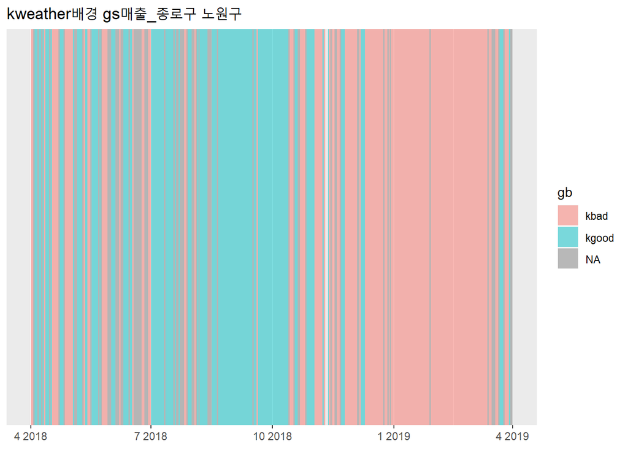

```r
gs4.sum %>% ggplot +    geom_rect(aes(xmin = DT, xmax = DT+1, fill=gb), ymin = -Inf, ymax = Inf, alpha =0.5) +
    ggtitle(paste0("kweather배경 gs매출_","종로구 노원구"))
```

##### 종로구와 노원구 GS총매출의 일별 평균을 보면 여름에 높고 겨울에 낮다. 총매출 역시 계절성을 띈다.

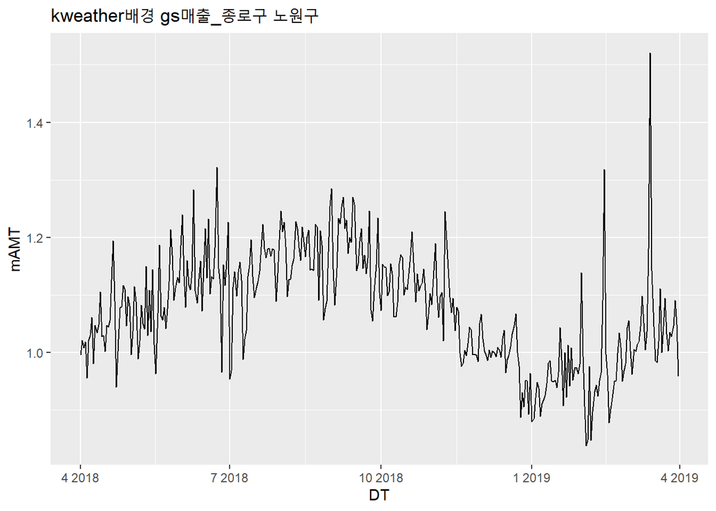

```r
gs4.sum %>% ggplot + geom_line(stat = 'identity',  aes(DT, mAMT)) +
    ggtitle(paste0("kweather배경 gs매출_","종로구 노원구"))
```

##### 둘을 겹쳐서 그려보면 아래와 같다.

##### 빨간 가로선은 종로구와 노원구 총매출의 일별 평균을 일마다 낸 365개 값의 중앙값이다.

##### 파란 세로선은 월 구분 선이다.

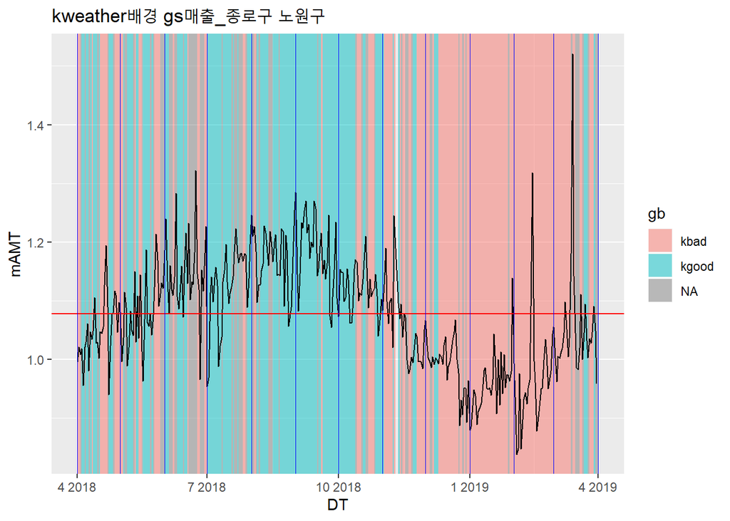

```r
gs4.sum %>% ggplot +    geom_rect(aes(xmin = DT, xmax = DT+1, fill=gb), ymin = -Inf, ymax = Inf, alpha =0.5)+
      geom_line(stat = 'identity',  aes(DT, mAMT)) +
        geom_hline(yintercept = median(gs4.sum$mAMT), col = "red")+
    geom_vline(xintercept=as.Date(c("2018-04-01","2018-05-01","2018-06-01","2018-07-01",
        "2018-08-01","2018-09-01","2018-10-01","2018-11-01","2018-12-01",
        "2019-01-01","2019-02-01","2019-03-01","2019-04-01")), color='blue', size=0.1) +
    ggtitle(paste0("kweather배경 gs매출_","종로구 노원구"))
```

##### 미세먼지도 계절성을 따르고, 매출도 계절성을 따른다. 따라서 미세먼지와 매출의 연관성은 계절을 통제했을 때 없을 수도 있다.

##### 따라서, 월별이라는 범주형 변수를 통제한 상태에서도 미세먼지의 좋고나쁨과 GS총매출의 높고낮음이 서로 연관이 있는지 Mantel Haenszel test로 확인해보자.

##### 귀무가설: 월 변수를 통제했을때, 미세먼지의 좋고나쁨과 GS총매출의 높고 낮음은 독립이다. 서로 연관이 없다.

##### 대립가설: 월 변수 요인을 제거했을 때, 미세먼지의 좋고나쁨과 GS총매출의 높고 낮음은 서로 독립이 아니고 연관이 있다.

```r
for(i in 1:36){
    hdong = unique(gs5$HDONG)[i]
    for_gs = gs5 %>% filter(HDONG == hdong)
    hdong_med = median(for_gs$AMT_IND, na.rm = T)
    for_gs$COUNT = ifelse(for_gs$AMT_IND > hdong_med,"upper", "lower")
    fgs = for_gs %>% separate(DT, c("Y","M","D"), c(4,-2))
    print('')
    print(paste(hdong, "월 수준에 따라 미먼과 gs매출이 차이가 나는지"))
    print((mantelhaen.test(xtabs(~COUNT+gb+M, data = fgs)))$p.value)
}
```

```
## [1] ""
## [1] "J청운효자동 월 수준에 따라 미먼과 gs매출이 차이가 나는지"
## [1] 0.03603846
## [1] ""
## [1] "J사직동 월 수준에 따라 미먼과 gs매출이 차이가 나는지"
## [1] 0.08783804
## [1] ""
## [1] "J삼청동 월 수준에 따라 미먼과 gs매출이 차이가 나는지"
## [1] 0.5307085
## [1] ""
## [1] "J부암동 월 수준에 따라 미먼과 gs매출이 차이가 나는지"
## [1] 0.2436905
## [1] ""
## [1] "J평창동 월 수준에 따라 미먼과 gs매출이 차이가 나는지"
## [1] 0.3382025
```

[output cut: 93 more lines]

##### 유의수준 0.05하에서, 36개의 동 중 32개의 동은 귀무가설을 기각하지 못한다.

##### **종로구의 청운효자동, 노원구의 월계2동,중계2·3동,상계10동** 만이 귀무가설을 기각한다.

##### 이 4개의 동은 월 변수 요인과 관계없이, 미세먼지의 좋고나쁨은 GS총매출의 높고낮음과 연관이 있다.

##### 이 **4개의 동은 GS 총매출이 미세먼지에 민감한 지역**이라 생각할 수 있다.

# 2. 상품군 별 매출

##### 데이터의 형태를 바꾸자

```r
# gs.kgb는 이상치 처리된 gs로 생성된 데이터라 이상치 제거를 하지 않음
gs.kgb2 = gs.kgb %>% gather( c("mAMT",paste0('m',1:8,'0')) , key = 'CAT', value = "amt" )
```

##### 36개동의 미세머지 좋은날, 나쁜날 GS 카테고리별 매출 평균을 비교해보았다. 미세먼지 나쁜 날의 매출 평균이 더 높은 동의 개수와, 36개 동 중의 percent로 표시했다. 주중, 주말로 나누어 살펴봤다.

##### 음료는 항상 미세먼지 나쁜날 매출액 평균이 항상 더 낮고, 간식은 63.9~66.7%의 동이 미세먼지가 나쁜 날 매출량 평균이 더 높다.

```r
gs.kgb2$CAT = factor(gs.kgb2$CAT)
a = round(table(gs.kgb2  %>% filter(gb == 'ratio', weekend == '주중', amt >= 1) %>% select(CAT))/36 , 3)
b = round(table(gs.kgb2  %>% filter(gb == 'ratio', weekend == '주말', amt >= 1) %>% select(CAT))/36 , 3)
c = round(table(gs.kgb2  %>% filter(gb == 'ratio',amt >= 1) %>% select(CAT))/72 , 3)
aa = table(gs.kgb2  %>% filter(gb == 'ratio', weekend == '주중', amt >= 1) %>% select(CAT))
bb = table(gs.kgb2  %>% filter(gb == 'ratio', weekend == '주말', amt >= 1) %>% select(CAT))
cc = table(gs.kgb2  %>% filter(gb == 'ratio',amt >= 1) %>% select(CAT))


abc = rbind(aa,a,bb,b,cc,c)
rownames(abc) = c("주중 count", "주중 percent", "주말 count", "주말 percent", "전체 count", "전체 percent")
abc
```

```
##                m10    m20 m30    m40   m50    m60    m70    m80  mAMT
## 주중 count   6.000 23.000   0 15.000 7.000  4.000 16.000  6.000 1.000
## 주중 percent 0.167  0.639   0  0.417 0.194  0.111  0.444  0.167 0.028
## 주말 count   2.000 24.000   0 15.000 2.000 16.000 11.000 10.000 1.000
## 주말 percent 0.056  0.667   0  0.417 0.056  0.444  0.306  0.278 0.028
## 전체 count   8.000 47.000   0 30.000 9.000 20.000 27.000 16.000 2.000
## 전체 percent 0.111  0.653   0  0.417 0.125  0.278  0.375  0.222 0.028
```

```r
write.csv(abc, 'gs ratio table.csv')
```